# Mini Data Analysis Milestone 2

*To complete this milestone, you can either edit [this `.rmd` file](https://raw.githubusercontent.com/UBC-STAT/stat545.stat.ubc.ca/master/content/mini-project/mini-project-2.Rmd) directly. Fill in the sections that are commented out with `<!--- start your work here--->`. When you are done, make sure to knit to an `.md` file by changing the output in the YAML header to `github_document`, before submitting a tagged release on canvas.*

# Welcome to the rest of your mini data analysis project!

In Milestone 1, you explored your data. and came up with research questions. This time, we will finish up our mini data analysis and obtain results for your data by:

- Making summary tables and graphs
- Manipulating special data types in R: factors and/or dates and times.
- Fitting a model object to your data, and extract a result.
- Reading and writing data as separate files.

We will also explore more in depth the concept of *tidy data.*

**NOTE**: The main purpose of the mini data analysis is to integrate what you learn in class in an analysis. Although each milestone provides a framework for you to conduct your analysis, it’s possible that you might find the instructions too rigid for your data set. If this is the case, you may deviate from the instructions – just make sure you’re demonstrating a wide range of tools and techniques taught in this class.

# Instructions

**To complete this milestone**, edit [this very `.Rmd` file](https://raw.githubusercontent.com/UBC-STAT/stat545.stat.ubc.ca/master/content/mini-project/mini-project-2.Rmd) directly. Fill in the sections that are tagged with `<!--- start your work here--->`.

**To submit this milestone**, make sure to knit this `.Rmd` file to an `.md` file by changing the YAML output settings from `output: html_document` to `output: github_document`. Commit and push all of your work to your mini-analysis GitHub repository, and tag a release on GitHub. Then, submit a link to your tagged release on canvas.

**Points**: This milestone is worth 50 points: 45 for your analysis, and 5 for overall reproducibility, cleanliness, and coherence of the Github submission.

**Research Questions**: In Milestone 1, you chose two research questions to focus on. Wherever realistic, your work in this milestone should relate to these research questions whenever we ask for justification behind your work. In the case that some tasks in this milestone don’t align well with one of your research questions, feel free to discuss your results in the context of a different research question.

# Learning Objectives

By the end of this milestone, you should:

- Understand what *tidy* data is, and how to create it using `tidyr`.
- Generate a reproducible and clear report using R Markdown.
- Manipulating special data types in R: factors and/or dates and times.
- Fitting a model object to your data, and extract a result.
- Reading and writing data as separate files.

# Setup

Begin by loading your data and the tidyverse package below:

```r
setwd("/Users/nicholaswright/Desktop/mda-nickswright/Nicholas_Wright_DataProject/mda-nickswright/Mini_Project_2")
```

```r
library(datateachr)
library(tidyverse)
library(dplyr)
library(here)
```

# Task 1: Process and summarize your data

From milestone 1, you should have an idea of the basic structure of your dataset (e.g. number of rows and columns, class types, etc.). Here, we will start investigating your data more in-depth using various data manipulation functions.

### 1.1 (1 point)

First, write out the 4 research questions you defined in milestone 1 were. This will guide your work through milestone 2:

Research questions:

1. Are intensity of minimum and maximum flows correlated each year? Do some years tend to be wet years and some are dry year or if instead minimum and maximum flows are decoupled.
2. Are there significant differences between the annual maximum flows of each each decade? 1921-1930, 1931-1940, etc.
3. Have annual minimum flows changed over the time period of this study?
4. Are there significant differences between the intensity of annual maximum flows recorded in different months?

Here, we will investigate your data using various data manipulation and graphing functions.

### 1.2 (8 points)

Now, for each of your four research questions, choose one task from options 1-4 (summarizing), and one other task from 4-8 (graphing). You should have 2 tasks done for each research question (8 total). Make sure it makes sense to do them! (e.g. don’t use a numerical variables for a task that needs a categorical variable.). Comment on why each task helps (or doesn’t!) answer the corresponding research question.

Ensure that the output of each operation is printed!

Also make sure that you’re using dplyr and ggplot2 rather than base R. Outside of this project, you may find that you prefer using base R functions for certain tasks, and that’s just fine! But part of this project is for you to practice the tools we learned in class, which is dplyr and ggplot2.

**Summarizing:**

1. Compute the *range*, *mean*, and *two other summary statistics* of **one numerical variable** across the groups of **one categorical variable** from your data.
2. Compute the number of observations for at least one of your categorical variables. Do not use the function `table()`!
3. Create a categorical variable with 3 or more groups from an existing numerical variable. You can use this new variable in the other tasks! *An example: age in years into “child, teen, adult, senior”.*
4. Compute the proportion and counts in each category of one categorical variable across the groups of another categorical variable from your data. Do not use the function `table()`!

**Graphing:**

6. Create a graph of your choosing, make one of the axes logarithmic, and format the axes labels so that they are “pretty” or easier to read.
7. Make a graph where it makes sense to customize the alpha transparency.

Using variables and/or tables you made in one of the “Summarizing” tasks:

8. Create a graph that has at least two geom layers.
9. Create 3 histograms, with each histogram having different sized bins. Pick the “best” one and explain why it is the best.

Make sure it’s clear what research question you are doing each operation for!

### Are minimum and maximum flows correlated?

```r
glimpse(flow_sample)
```

```
## Rows: 218
## Columns: 7
## $ station_id   <chr> "05BB001", "05BB001", "05BB001", "05BB001", "05BB001", "0…
## $ year         <dbl> 1909, 1910, 1911, 1912, 1913, 1914, 1915, 1916, 1917, 191…
## $ extreme_type <chr> "maximum", "maximum", "maximum", "maximum", "maximum", "m…
## $ month        <dbl> 7, 6, 6, 8, 6, 6, 6, 6, 6, 6, 6, 7, 6, 6, 6, 7, 5, 7, 6, …
## $ day          <dbl> 7, 12, 14, 25, 11, 18, 27, 20, 17, 15, 22, 3, 9, 5, 14, 5…
## $ flow         <dbl> 314, 230, 264, 174, 232, 214, 236, 309, 174, 345, 185, 24…
## $ sym          <chr> NA, NA, NA, NA, NA, NA, NA, NA, NA, NA, NA, NA, NA, NA, N…
```

```r
data_summary <- flow_sample  %>%
   group_by(extreme_type) %>%
  summarize(
    flow_range = range(flow, na.rm=TRUE),
    flow_mean = mean(flow, na.rm=TRUE),
    flow_sd = sd(flow, na.rm=TRUE),
    flow_IQR = IQR(flow, na.rm=TRUE)
  )
data_summary
```

```
## # A tibble: 4 × 5
## # Groups:   extreme_type [2]
##   extreme_type flow_range flow_mean flow_sd flow_IQR
##   <chr>             <dbl>     <dbl>   <dbl>    <dbl>
## 1 maximum          107       212.    61.7      80
## 2 maximum          466       212.    61.7      80
## 3 minimum            3.62      6.27   0.965     1.26
## 4 minimum            8.44      6.27   0.965     1.26
```

Before analyzing whether minimum and maximum flows are correlated I wanted to examine some summary statistics for both of them. I found that the mean, range, interquartile range, and standard deviation are much higher for maximum flows than minimum flows, which will make them challenging to graphically compare.

```r
bin_edges <- c(0, 6.27, 9, 212, 467)
bin_labels <- c("Low Minimum", "High Minimum", "Low Maximum", "High Maximum")
flow_sample_breaks <- flow_sample %>%
  mutate(Flow_Intensity = cut(flow, breaks = bin_edges, labels = bin_labels, include.lowest = TRUE))

category_colors <- c("Low Minimum" = "red", "High Minimum" = "blue", "Low Maximum" = "red", "High Maximum" = "blue")
flow_sample_correlation <- flow_sample_breaks %>% filter(year>1998) %>%
ggplot(aes(x=year, y=flow, col=Flow_Intensity)) +
  geom_point() +
  theme_minimal() +
  xlab("Year") +
  ylab("Flow") +
  scale_color_manual(values = category_colors)
  scale_y_log10()
```

```
## <ScaleContinuousPosition>
##  Range:
##  Limits:    0 --    1
```

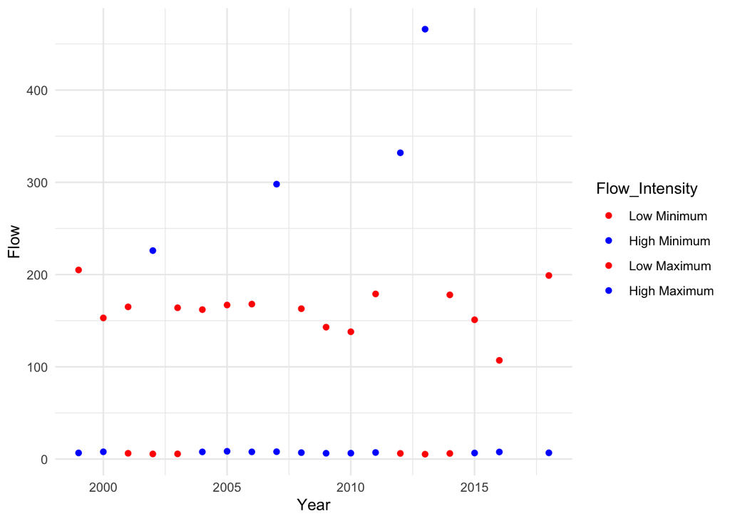

```r
flow_sample_correlation
```

### Are there differences between the maximum flows of each decade?

```r
bin_edges <- c(1900, 1919, 1929, 1939, 1949, 1959, 1969, 1979, 1989, 1999, 2009, 2019)
bin_labels <- c("1910s", "1920s", "1930s", "1940s", "1950s", "1960s", "1970s", "1980s", "1990s", "2000s", "2010s")
flow_sample_decades <- flow_sample %>%
  mutate(Decades = cut(year, breaks = bin_edges, labels = bin_labels, include.lowest = TRUE))

flow_sample_decades
```

```
## # A tibble: 218 × 8
##    station_id  year extreme_type month   day  flow sym   Decades
##    <chr>      <dbl> <chr>        <dbl> <dbl> <dbl> <chr> <fct>
##  1 05BB001     1909 maximum          7     7   314 <NA>  1910s
##  2 05BB001     1910 maximum          6    12   230 <NA>  1910s
##  3 05BB001     1911 maximum          6    14   264 <NA>  1910s
##  4 05BB001     1912 maximum          8    25   174 <NA>  1910s
##  5 05BB001     1913 maximum          6    11   232 <NA>  1910s
##  6 05BB001     1914 maximum          6    18   214 <NA>  1910s
##  7 05BB001     1915 maximum          6    27   236 <NA>  1910s
##  8 05BB001     1916 maximum          6    20   309 <NA>  1910s
##  9 05BB001     1917 maximum          6    17   174 <NA>  1910s
## 10 05BB001     1918 maximum          6    15   345 <NA>  1910s
## # ℹ 208 more rows
```

I mutated the numerical years variable into an ordinal categorical variable of decades. Each decade starts with a year ending in 0 and ends with a year ending in 9 and has 10 years within. The exceptions are the first decade (to which I added 1909) and the last decade (which ends with 2018).

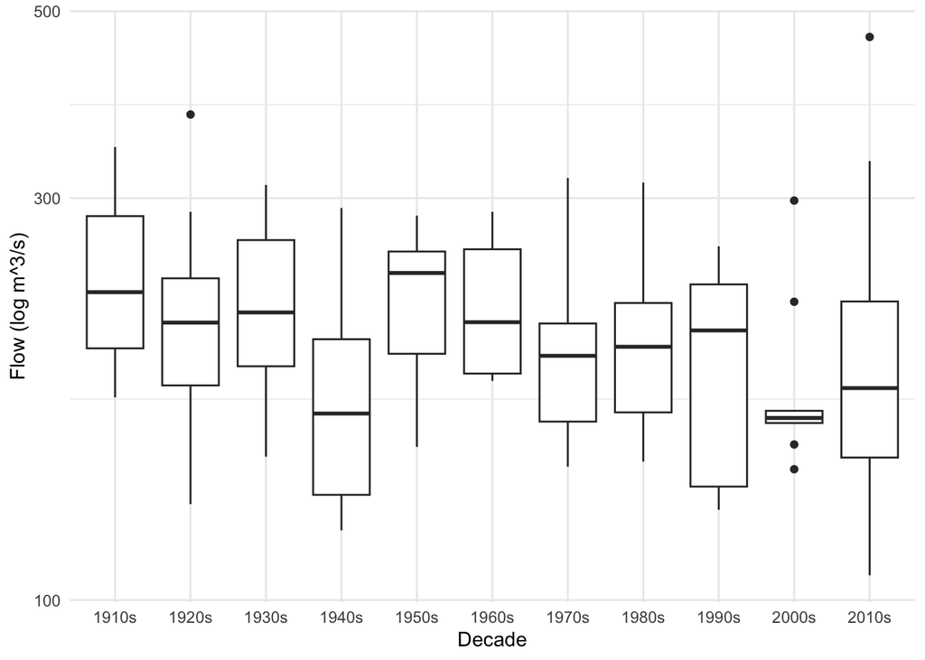

```r
flow_sample_decades %>% filter(extreme_type == "maximum") %>%
ggplot(aes(x=Decades, y=flow)) +
  geom_boxplot() +
  xlab("Decade") +
  ylab("Flow (log m^3/s)") +
  theme_minimal() +
  scale_y_log10()
```

### Have minimum flows changed over time?

```r
bin_edges <- c(1909, 1936, 1983, 2018)
bin_labels <- c("Period 1", "Period 2", "Period 3")
flow_sample_periods <- flow_sample %>% filter(extreme_type == "minimum") %>%
  mutate(Periods = cut(year, breaks = bin_edges, labels = bin_labels, include.lowest = TRUE))

flow_sample_periods
```

```
## # A tibble: 109 × 8
##    station_id  year extreme_type month   day  flow sym   Periods
##    <chr>      <dbl> <chr>        <dbl> <dbl> <dbl> <chr> <fct>
##  1 05BB001     1909 minimum         NA    NA NA    <NA>  Period 1
##  2 05BB001     1910 minimum         NA    NA NA    <NA>  Period 1
##  3 05BB001     1911 minimum          2    27  5.75 <NA>  Period 1
##  4 05BB001     1912 minimum          3    14  5.8  <NA>  Period 1
##  5 05BB001     1913 minimum          3    18  6.12 B     Period 1
##  6 05BB001     1914 minimum         11    17  7.16 <NA>  Period 1
##  7 05BB001     1915 minimum          1    27  6.94 <NA>  Period 1
##  8 05BB001     1916 minimum          3     2  6.97 B     Period 1
##  9 05BB001     1917 minimum          2    23  6.06 B     Period 1
## 10 05BB001     1918 minimum          2    20  6.03 B     Period 1
## # ℹ 99 more rows
```

I changed the numerical “years” variable into an ordinal categorical “periods’ variable that divided the time period of this dataset into 3.

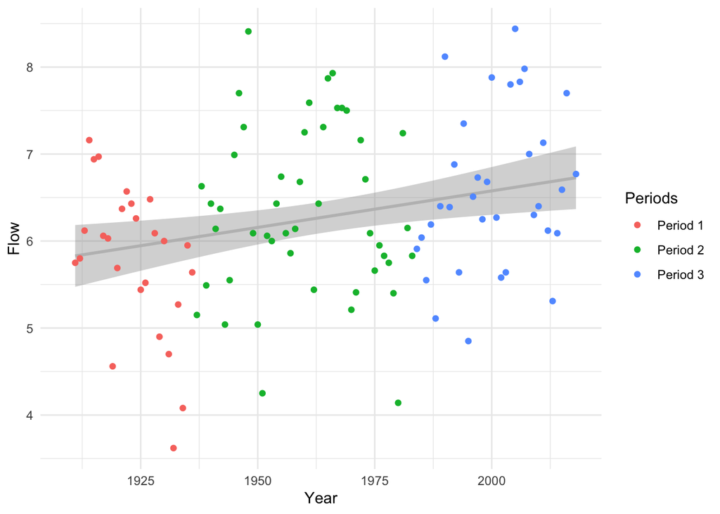

```r
flow_sample_minimum <- flow_sample_periods %>% filter(extreme_type == "minimum")
ggplot(flow_sample_minimum, aes(x=year, y=flow, col = Periods, na.rm=TRUE)) +
  geom_smooth(method=lm, colour="grey") +
  geom_point() +
  theme_minimal() +
  xlab("Year") +
  ylab("Flow")
```

I used a scatterplot and added a trend line to be able to visualize the change of minimum flows across the study period. I also colored the points by time period to help look for differences between the periods. This graph appears to disprove my hypothesis that minimum flows would decrease over the course of the study period due to climate change induced drought.

### Are there differences between intensity of maximum flows recorded each month?

```r
flow_sample %>% filter(extreme_type == "maximum") %>% count(month)
```

```
## # A tibble: 4 × 2
##   month     n
##   <dbl> <int>
## 1     5    16
## 2     6    79
## 3     7    13
## 4     8     1
```

This count shows that annual maximum flows were recorded in May, June, July, and August. By far the most maximum flows were recorded in June. Similar numbers were recorded in May and July. I am going to exclude August from my next graphs because there is only one observation.

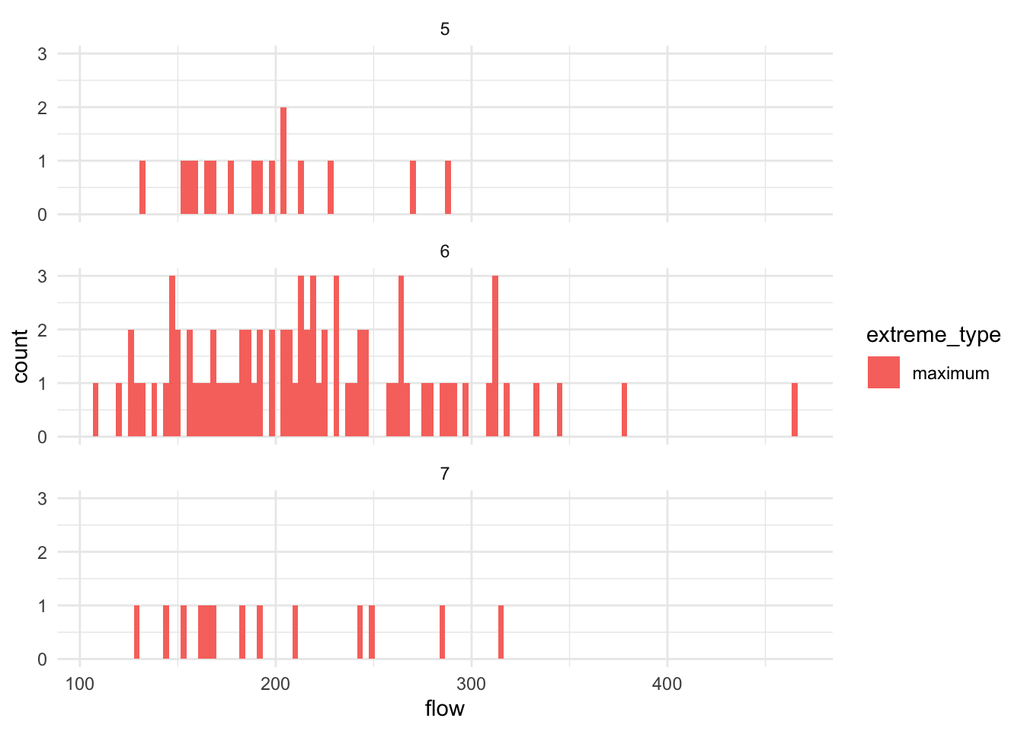

```r
flow_sample1 <- flow_sample %>% filter(month == "5" | month=="6" | month=="7")
  ggplot(flow_sample1, aes(x=flow, fill=extreme_type)) +
    geom_histogram(binwidth = 3) +
    theme_minimal() +
    facet_wrap(~month, ncol=1) #To put all 3 graphs in the same column
```

Using a small bin width I can see that June has the widest range of values. It is challenging to compare between months with this bin size. I can see one extremely high flow in June.

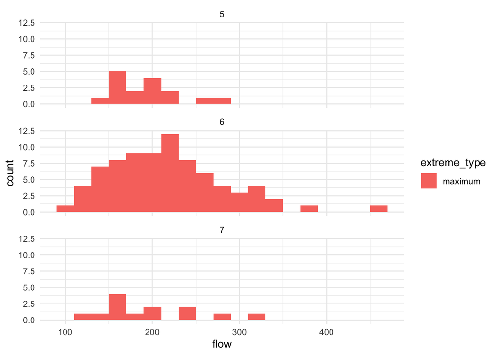

```r
  flow_sample1 <- flow_sample %>% filter(month == "5" | month=="6" | month=="7")
  ggplot(flow_sample1, aes(x=flow, fill=extreme_type)) +
    geom_histogram(binwidth = 20) +
    theme_minimal() +
    facet_wrap(~month, ncol=1)
```

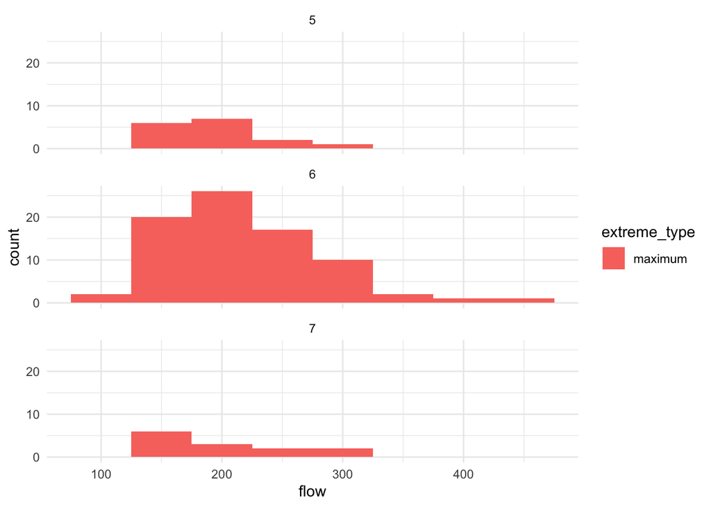

```r
    flow_sample1 <- flow_sample %>% filter(month == "5" | month=="6" | month=="7")
  ggplot(flow_sample1, aes(x=flow, fill=extreme_type)) +
    geom_histogram(binwidth = 50) +
    theme_minimal() +
    facet_wrap(~month, ncol=1)
```

I find using a very wide bin width preferable to very small, but still not ideal. The advantage is that it is easy to quickly look at and see trends. However, some level of detail is lost–for example I can’t tell precisely what flow was recorded most frequently in June.

### 1.3 (2 points)

Based on the operations that you’ve completed, how much closer are you to answering your research questions? Think about what aspects of your research questions remain unclear. Can your research questions be refined, now that you’ve investigated your data a bit more? Which research questions are yielding interesting results?

I think all of these methods advanced my understanding of the questions I posed. Here are my main takeaways from each analysis:

1. Intensity of minimum and maximum flows do not appear to be correlated during the most recent 20 years. However, I would need to run a statistical model to really test that for the duration of the study period.
2. There are clearly differences in mean, IQR, and range between the maximimum flows of each decade, although these differences don’t appear to be huge. I would need to run a model to trust whether any of the years are significantly different.
3. Minimum flow has increased across this study. It would be interesting to test whether there are any significant differences between the 3 time periods of the study.
4. There are clear differences between the maximum flows of May, June, and July. June in particular has far more data points than the other two months. I would be interested in in testing whether the means of the three months are significantly different.

# Task 2: Tidy your data

In this task, we will do several exercises to reshape our data. The goal here is to understand how to do this reshaping with the `tidyr` package.

A reminder of the definition of *tidy* data:

- Each row is an **observation**
- Each column is a **variable**
- Each cell is a **value**

### 2.1 (2 points)

Based on the definition above, can you identify if your data is tidy or untidy? Go through all your columns, or if you have >8 variables, just pick 8, and explain whether the data is untidy or tidy.

The flow sample data is tidy. Each row is an observation, each column is a variable, and each cell is a value. The columns station_id, year, extreme_type, month, date, flow, and sym are all variables.

### 2.2 (4 points)

Now, if your data is tidy, untidy it! Then, tidy it back to it’s original state.

If your data is untidy, then tidy it! Then, untidy it back to it’s original state.

Be sure to explain your reasoning for this task. Show us the “before” and “after”.

```r
flow_sample_wider <- flow_sample %>%
  select(year, extreme_type, flow) %>%
  pivot_wider(names_from = extreme_type,
              values_from = flow)

flow_sample_wider
```

```
## # A tibble: 109 × 3
##     year maximum minimum
##    <dbl>   <dbl>   <dbl>
##  1  1909     314   NA
##  2  1910     230   NA
##  3  1911     264    5.75
##  4  1912     174    5.8
##  5  1913     232    6.12
##  6  1914     214    7.16
##  7  1915     236    6.94
##  8  1916     309    6.97
##  9  1917     174    6.06
## 10  1918     345    6.03
## # ℹ 99 more rows
```

```r
# I first removed unnecessary columns and then did a univariate pivot to widen the data so I could compare the maximum and minimum flows each year. This data is no longer tidy because each row contains 2 observations, which are the max and min flows from that year.


flow_sample_longer <- flow_sample_wider %>% pivot_longer(cols = c(-year),
               names_to  = "extreme_type",
               values_to = "flow")

flow_sample_longer
```

```
## # A tibble: 218 × 3
##     year extreme_type   flow
##    <dbl> <chr>         <dbl>
##  1  1909 maximum      314
##  2  1909 minimum       NA
##  3  1910 maximum      230
##  4  1910 minimum       NA
##  5  1911 maximum      264
##  6  1911 minimum        5.75
##  7  1912 maximum      174
##  8  1912 minimum        5.8
##  9  1913 maximum      232
## 10  1913 minimum        6.12
## # ℹ 208 more rows
```

```r
# I then did another univariate pivot using the pivot_longer function to lengthen the data and make it tidy again.
```

### 2.3 (4 points)

Now, you should be more familiar with your data, and also have made progress in answering your research questions. Based on your interest, and your analyses, pick 2 of the 4 research questions to continue your analysis in the remaining tasks:

#### I am most interested in pursuing these questions:

1. Are intensity of minimum and maximum flows correlated each year? Do some years tend to be wet years and some are dry year or if instead minimum and maximum flows are decoupled.
2. Are there significant differences between the annual maximum flows of each each decade? 1921-1930, 1931-1940, etc.

I want to understand whether intensity of annual maximum and minimum flows are correlated for several reasons. First, I felt that graphing it could not really help me get a sense of the answer and I think running a statistical model would be essential. Second, I think that answering this question would provide insights into the environmental dynamics of this system. Specifically do we tend to see generally wet year and dry years? Or are minimum and maximum flows decoupled, which might be because minimum flows are determined by rainfall and maximum flows are determined by snow melt.

I want to come test whether there are differences between annual maximum flows on the decade time scale. I have already divided the dates into decades so I think that it would make sense to then compare these decades against each other. It will be interesting to analyze the amount of variation between decades, since some ecosystems experience high interannual variability in precipitation and some are quite stable. I think this question important for assessing whether we should prepare for long time periods of low or high flow that could lead to water shortages or flooding, respectively.

Now, try to choose a version of your data that you think will be appropriate to answer these 2 questions. Use between 4 and 8 functions that we’ve covered so far (i.e. by filtering, cleaning, tidy’ing, dropping irrelevant columns, etc).

(If it makes more sense, then you can make/pick two versions of your data, one for each research question.)

### Correlation Analysis Data Cleaning

```r
flow_sample_correlation_analysis <- flow_sample %>%  select(year, extreme_type, flow) %>%
 filter(year > 1910)

flow_sample_correlation_analysis
```

```
## # A tibble: 214 × 3
##     year extreme_type  flow
##    <dbl> <chr>        <dbl>
##  1  1911 maximum        264
##  2  1912 maximum        174
##  3  1913 maximum        232
##  4  1914 maximum        214
##  5  1915 maximum        236
##  6  1916 maximum        309
##  7  1917 maximum        174
##  8  1918 maximum        345
##  9  1919 maximum        185
## 10  1920 maximum        248
## # ℹ 204 more rows
```

I used a select function to get rid of unnecessary columns and then the filter funciton to remove the first two years of the study which had NA values for minimum flow.

### Decade Analysis Data Cleaning

```r
bin_edges <- c(1900, 1919, 1929, 1939, 1949, 1959, 1969, 1979, 1989, 1999, 2009, 2019)
bin_labels <- c("1910s", "1920s", "1930s", "1940s", "1950s", "1960s", "1970s", "1980s", "1990s", "2000s", "2010s")
flow_sample_decades <- flow_sample %>%
  mutate(Decades = cut(year, breaks = bin_edges, labels = bin_labels, include.lowest = TRUE))

flow_sample_decades
```

```
## # A tibble: 218 × 8
##    station_id  year extreme_type month   day  flow sym   Decades
##    <chr>      <dbl> <chr>        <dbl> <dbl> <dbl> <chr> <fct>
##  1 05BB001     1909 maximum          7     7   314 <NA>  1910s
##  2 05BB001     1910 maximum          6    12   230 <NA>  1910s
##  3 05BB001     1911 maximum          6    14   264 <NA>  1910s
##  4 05BB001     1912 maximum          8    25   174 <NA>  1910s
##  5 05BB001     1913 maximum          6    11   232 <NA>  1910s
##  6 05BB001     1914 maximum          6    18   214 <NA>  1910s
##  7 05BB001     1915 maximum          6    27   236 <NA>  1910s
##  8 05BB001     1916 maximum          6    20   309 <NA>  1910s
##  9 05BB001     1917 maximum          6    17   174 <NA>  1910s
## 10 05BB001     1918 maximum          6    15   345 <NA>  1910s
## # ℹ 208 more rows
```

```r
flow_sample_decades_analysis <- flow_sample_decades %>%
  select(year, extreme_type, flow, Decades) %>%
  filter(extreme_type == "maximum")

flow_sample_decades_analysis
```

```
## # A tibble: 109 × 4
##     year extreme_type  flow Decades
##    <dbl> <chr>        <dbl> <fct>
##  1  1909 maximum        314 1910s
##  2  1910 maximum        230 1910s
##  3  1911 maximum        264 1910s
##  4  1912 maximum        174 1910s
##  5  1913 maximum        232 1910s
##  6  1914 maximum        214 1910s
##  7  1915 maximum        236 1910s
##  8  1916 maximum        309 1910s
##  9  1917 maximum        174 1910s
## 10  1918 maximum        345 1910s
## # ℹ 99 more rows
```

# Task 3: Modelling

## 3.0 (no points)

**Research Question**: Are there significant differences in intensity of maximum flows between decades?

**Variable of interest**: Explanatory variable-Decade, Response variable-Flow

## 3.1 (3 points)

Fit a model or run a hypothesis test that provides insight on this variable with respect to the research question. Store the model object as a variable, and print its output to screen. We’ll omit having to justify your choice, because we don’t expect you to know about model specifics in STAT 545.

- **Note**: It’s OK if you don’t know how these models/tests work. Here are some examples of things you can do here, but the sky’s the limit.
  - You could fit a model that makes predictions on Y using another variable, by using the `lm()` function.
  - You could test whether the mean of Y equals 0 using `t.test()`, or maybe the mean across two groups are different using `t.test()`, or maybe the mean across multiple groups are different using `anova()` (you may have to pivot your data for the latter two).
  - You could use `lm()` to test for significance of regression coefficients.

```r
anova_result <- aov(flow ~ Decades, data = flow_sample_decades_analysis)
anova_result
```

```
## Call:
##    aov(formula = flow ~ Decades, data = flow_sample_decades_analysis)
##
## Terms:
##                  Decades Residuals
## Sum of Squares   45086.9  365838.5
## Deg. of Freedom       10        98
##
## Residual standard error: 61.09866
## Estimated effects may be unbalanced
```

## 3.2 (3 points)

Produce something relevant from your fitted model: either predictions on Y, or a single value like a regression coefficient or a p-value.

- Be sure to indicate in writing what you chose to produce.
- Your code should either output a tibble (in which case you should indicate the column that contains the thing you’re looking for), or the thing you’re looking for itself.
- Obtain your results using the `broom` package if possible. If your model is not compatible with the broom function you’re needing, then you can obtain your results by some other means, but first indicate which broom function is not compatible.

```r
decade_tidy <- broom::tidy(anova_result)
print(decade_tidy)
```

```
## # A tibble: 2 × 6
##   term         df   sumsq meansq statistic p.value
##   <chr>     <dbl>   <dbl>  <dbl>     <dbl>   <dbl>
## 1 Decades      10  45087.  4509.      1.21   0.296
## 2 Residuals    98 365839.  3733.     NA     NA
```

```r
summary(anova_result)
```

```
##             Df Sum Sq Mean Sq F value Pr(>F)
## Decades     10  45087    4509   1.208  0.296
## Residuals   98 365839    3733
```

I used an ANOVA to compare the flow means between decades. Using the broom:tidy function I produced a tibble with results. The p-value is 0.295, indicating the there are not significant differences between the means of the different decades. I also ran a summary function and found that the F-value is 1.208. With this information I can not reject the null hypothesis that there are no significant differences in flow between decades.

# Task 4: Reading and writing data

Get set up for this exercise by making a folder called `output` in the top level of your project folder / repository. You’ll be saving things there.

## 4.1 (3 points)

Take a summary table that you made from Task 1, and write it as a csv file in your `output` folder. Use the `here::here()` function.

- **Robustness criteria**: You should be able to move your Mini Project repository / project folder to some other location on your computer, or move this very Rmd file to another location within your project repository / folder, and your code should still work.
- **Reproducibility criteria**: You should be able to delete the csv file, and remake it simply by knitting this Rmd file.

```r
Summary_Table <- data_summary

write.csv(Summary_Table, file = here::here("output/Summary_Table.csv"))
```

## 4.2 (3 points)

Write your model object from Task 3 to an R binary file (an RDS), and load it again. Be sure to save the binary file in your `output` folder. Use the functions `saveRDS()` and `readRDS()`.

- The same robustness and reproducibility criteria as in 4.1 apply here.

```r
decades_model <- here::here("output", "decades_anova.rds")
saveRDS(anova_result, file = decades_model)

cat("Model object saved to:", decades_model, "\n")
```

```
## Model object saved to: /Users/nicholaswright/Desktop/mda-nickswright/Nicholas_Wright_DataProject/mda-nickswright/output/decades_anova.rds
```

```r
load_saved_model <- readRDS(decades_model)

print(load_saved_model)
```

```
## Call:
##    aov(formula = flow ~ Decades, data = flow_sample_decades_analysis)
##
## Terms:
##                  Decades Residuals
## Sum of Squares   45086.9  365838.5
## Deg. of Freedom       10        98
##
## Residual standard error: 61.09866
## Estimated effects may be unbalanced
```

# Overall Reproducibility/Cleanliness/Coherence Checklist

Here are the criteria we’re looking for.

## Coherence (0.5 points)

The document should read sensibly from top to bottom, with no major continuity errors.

The README file should still satisfy the criteria from the last milestone, i.e. it has been updated to match the changes to the repository made in this milestone.

## File and folder structure (1 points)

You should have at least three folders in the top level of your repository: one for each milestone, and one output folder. If there are any other folders, these are explained in the main README.

Each milestone document is contained in its respective folder, and nowhere else.

Every level-1 folder (that is, the ones stored in the top level, like “Milestone1” and “output”) has a `README` file, explaining in a sentence or two what is in the folder, in plain language (it’s enough to say something like “This folder contains the source for Milestone 1”).

## Output (1 point)

All output is recent and relevant:

- All Rmd files have been `knit`ted to their output md files.
- All knitted md files are viewable without errors on Github. Examples of errors: Missing plots, “Sorry about that, but we can’t show files that are this big right now” messages, error messages from broken R code
- All of these output files are up-to-date – that is, they haven’t fallen behind after the source (Rmd) files have been updated.
- There should be no relic output files. For example, if you were knitting an Rmd to html, but then changed the output to be only a markdown file, then the html file is a relic and should be deleted.

Our recommendation: delete all output files, and re-knit each milestone’s Rmd file, so that everything is up to date and relevant.

## Tagged release (0.5 point)

You’ve tagged a release for Milestone 2.

### Attribution

Thanks to Victor Yuan for mostly putting this together.